# Plotting in Python

### Matplotlib, Seaborn, Bokeh, and APLpy

Kevin Gullikson

# Outline

- Matplotlib
  - Basics
  - Latex
  - legends
  - Annotation
  - Multiple axes
  - Multiple subplots
- Seaborn: Pretty colors, easy configuration
- Bokeh
  - hover tooltips
  - linked brushing
- APLpy: Astronomy plotting library

#### All images and source for this slideshow are available [here](https://github.com/OttoStruve/GSPS/tree/master/Kevin-Mar2015)

[figure not shown]

### Aims to make easy things easy, and difficult things possible.

- Main plotting library
- Almost everyone has it
- [Extensive gallery](http://matplotlib.org/gallery.html)
- Jet == sad panda

# Basic Plotting

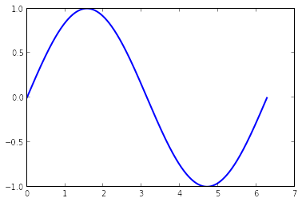

```python
x = np.arange(0, 2.0*np.pi, 0.01)   # I think the IDL equivalent is findgen...
y = np.sin(x)

fig, ax = pylab.subplots()
_ = ax.plot(x,y, lw=2)
```

# Axis Labels

```python
ax.set_xlabel('Time', fontsize=15)
ax.set_ylabel('Value', fontsize=15)
```

[figure not shown]

# Legends + LaTex

```python
_ = ax.plot(x,y1, lw=2, label=r'$\nu = 1 s^{-1}$')
_ = ax.plot(x,y2, lw=2, label=r'$\nu = 2 s^{-1}$')
leg = ax.legend(loc='best', fancybox=True)
leg.get_frame().set_alpha(0.5)
```

[figure not shown]

# Annotation

```python
# Adjust axes
ax.set_ylim((-1.2, 1.3))
ax.set_xlim((0, 2.0*np.pi))

ax.annotate('Peak', xy=(np.pi/2, 1), xytext=(np.pi, 1.1),
            arrowprops=dict(facecolor='black', # Arrow color
                            shrink=0.1,        # Distance between arrow and text
                            width=2),          # Width of the arrow, in points
            fontsize=15)
```

[figure not shown]

# Adding axes

- For a full example, see what I did [here](http://nbviewer.ipython.org/gist/anonymous/d07e8d89d16eaea92b7d) (It uses data on my local computer, so you won't be able to run it as-is)
- Here is the relevent code

```python
def add_top_axis(axis, spt_values=('M5', 'M0', 'K5', 'K0', 'G5', 'G0')):
    # Find the temperatures at each spectral type
    temp_values = MS.Interpolate('Temperature', spt_values)

    # make the axis
    top = axis.twiny()

    # Set the full range to be the same as the data axis
    xlim = axis.get_xlim()
    top.set_xlim(xlim)

    # Set the ticks at the temperatures corresponding to the right spectral type
    top.set_xticks(temp_values)
    top.set_xticklabels(spt_values)
    top.set_xlabel('Spectral Type')
    return top
```

[figure not shown]

# Subplots

```python
from matplotlib import gridspec

fig = pylab.figure()
gs = gridspec.GridSpec(2, 1, height_ratios=[3, 1.5])
top = plt.subplot(gs[0])
top.plot(xdata, ydata, 'rx')
top.plot(xfull, yfull, 'k--', lw=2)
bottom = plt.subplot(gs[1])
bottom.plot(xdata, ydata-np.sin(xdata), 'rx', lw=2)
bottom.plot(xfull, np.zeros(xfull.size), 'k--')
```

[figure not shown]

# Setting Defaults

- ~/.matplotlib/matplotlibrc
  - backend : TkAgg
  - lines.linewidth : 1.0
  - Search github for matplotlibrc files
  - See [here](http://matplotlib.org/users/customizing.html) for documentation
- On top of the script

```python
import matplotlib
matplotlib.rc('lines', linewidth=2, color='r')

# Must edit the rc params before this (or pylab import)
import matplotlib.pyplot as plt
```

# [Seaborn](http://stanford.edu/~mwaskom/software/seaborn/)

- Aims to make plots prettier by default (jet not even available!)
- As easy as 'import seaborn as sns' on top of script
- Easy colormap changes
- Plays well with pandas
- Also has its own built-in functions for:
  - [Linear fitting and plotting the result](http://stanford.edu/~mwaskom/software/seaborn/examples/anscombes_quartet.html#anscombes-quartet)
  - [Visualizing matrices](http://stanford.edu/~mwaskom/software/seaborn/examples/heatmap_annotation.html#heatmap-annotation)
- Has its own [example gallery](http://stanford.edu/~mwaskom/software/seaborn/examples/index.html#example-gallery)

### "If matplotlib “tries to make easy things easy and hard things possible”, seaborn aims to make a well-defined set of hard things easy too.

[figure not shown]

# [Bokeh](http://bokeh.pydata.org/en/latest/)

- Make interactive plots via web presentation
- Similar to D3.js but you don't need to know any javascript.
- [Hover tooltips](http://bokeh.pydata.org/en/latest/docs/gallery/periodic.html)
- Streaming large data (eventually...)
- [Linked brushing](http://bokeh.pydata.org/en/latest/docs/server_gallery/stocks_server.html)
- Also has a gallery
- Takes a bit more work than seaborn
- Documentation is lacking and/or out of date, but the examples are really useful
- works in ipython notebook with %bokeh "magic"

[figure not shown]

# [APLpy](https://aplpy.github.io/): The Astronomical Plotting Library in Python

- Made specifically for astronomy plotting
- Reads in fits files
- Knows about RA/DEC coordinates and how we write them
- Has a (small) [gallery](http://aplpy.sourceforge.net/static_gallery_mirror/)

[figure not shown]

# Examples

[figure not shown]

Credit: Jacob Hummel. [Source](http://nbviewer.ipython.org/github/hummel/xray_notebooks/blob/master/Structure%20Visualization.ipynb)

[figure not shown]

Credit: Jacob Hummel. [Source](http://nbviewer.ipython.org/github/hummel/xray_notebooks/blob/master/Disk%20Structure.ipynb)

[figure not shown]

Credit: Aaron Jaurez.

[figure not shown]

Credit: Aaron Jaurez.

# Conclusions

- For line plots and scatter plots, use matplotlib. import seaborn for aesthetics
- For images, consider APLpy
- For interactive data vizualation, consider bokeh